# PPAR/RXR Motif Alignment and MEME Export

Eli Brouwer

2026-08-11

This file loads the HOCOMOCO and JASPAR PPAR/RXR motifs, aligns them alongside a reference PPRE motif, and exports them in MEME format for use as FIMO input.

```r
hocomoco_motif_directory = "data/PPAR_RXR_motifs_Hocomoco_Jaspar/HOCOMOCO"

jaspar_motif_directory = "data/PPAR_RXR_motifs_Hocomoco_Jaspar/JASPAR"
```

Load in both JASPAR and HOCOMOCO motifs and convert to PFM file structure.

```r
jaspar_motifs_lst <- list.files(jaspar_motif_directory)
for (i in 1:length(jaspar_motifs_lst)){
  pwm_matrix = getPwmFromPfmOrJasparFile(paste0(jaspar_motif_directory, "/", jaspar_motifs_lst[i]))
  write.table(pwm_matrix[,-1], file = paste0(jaspar_motif_directory, "/", file_path_sans_ext(jaspar_motifs_lst[i]), ".pwm"), sep = "\t", quote = FALSE, col.names = FALSE)
}
```

```r
# making a pfm list from jaspar
jaspar_motifs_pfm_lst <-  grep("\\.jaspar$", list.files(jaspar_motif_directory), value = TRUE)
jaspar_pfm_list <- list()
for (i in 1:length(jaspar_motifs_pfm_lst)){
  jaspar_pfm_list[[jaspar_motifs_pfm_lst[i]]] <- pcm2pfm(importMatrix(paste0(jaspar_motif_directory, "/", jaspar_motifs_pfm_lst[i]), to = "pcm"))[[1]]
}
```

```r
hocomoco_motifs_pfm_lst <- grep("\\.meme$", list.files(hocomoco_motif_directory), value = TRUE) # import all hocomoco

# Restrict to the 11 HOCOMOCO half-site motifs used in this alignment (matching
# `desired_order` below). RXRB.H13CORE.2.PS.A and the RXRG.H13CORE half-sites
# are intentionally excluded; the RXRG half-site is instead represented by the
# JASPAR motifs MA0856.1 and MA1556.1. Selecting by name (rather than by
# truncating to length(jaspar_motifs_pfm_lst), as before) keeps this list
# stable regardless of what else gets added to either motif directory.
hocomoco_motifs_pfm_lst <- hocomoco_motifs_pfm_lst[hocomoco_motifs_pfm_lst %in% c(
  "PPARA.H13CORE.0.P.B_meme_format.meme",
  "PPARA.H13CORE.1.P.B_meme_format.meme",
  "PPARD.H13CORE.0.PSM.A_meme_format.meme",
  "PPARG.H13CORE.0.P.B_meme_format.meme",
  "PPARG.H13CORE.1.P.B_meme_format.meme",
  "RXRA.H13CORE.0.PS.A_meme_format.meme",
  "RXRA.H13CORE.1.S.C_meme_format.meme",
  "RXRA.H13CORE.2.SM.B_meme_format.meme",
  "RXRA.H13CORE.3.P.B_meme_format.meme",
  "RXRB.H13CORE.0.P.C_meme_format.meme",
  "RXRB.H13CORE.1.SM.B_meme_format.meme"
)]

hocomoco_pfm_list <- list()
for (i in 1:length(hocomoco_motifs_pfm_lst)){
  hocomoco_pfm_list[[hocomoco_motifs_pfm_lst[i]]] <- importMatrix(paste0(hocomoco_motif_directory, "/", hocomoco_motifs_pfm_lst[i]))[[1]]
}
```

# 1 Reference PPRE Motif

A canonical PPRE (DR1) motif is defined manually as a reference for alignment and comparison against the HOCOMOCO and JASPAR motifs.

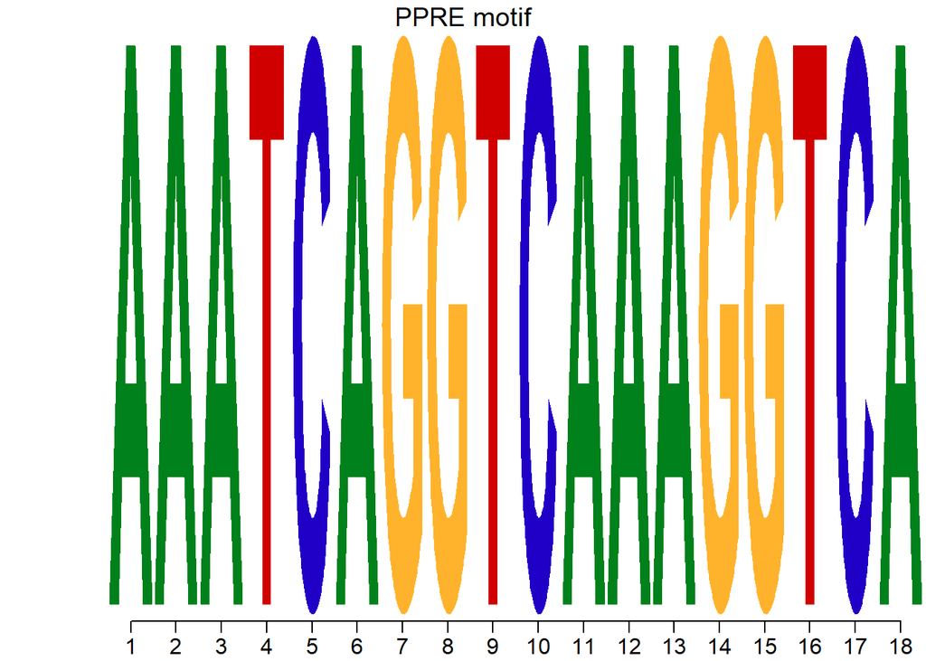

```r
PPRE_mat <- matrix(c(
  1,1,1,0,0,1,0,0,0,0,1,1,1,0,0,0,0,1,  # A
  0,0,0,0,1,0,0,0,0,1,0,0,0,0,0,0,1,0,  # C
  0,0,0,0,0,0,1,1,0,0,0,0,0,1,1,0,0,0,  # G
  0,0,0,1,0,0,0,0,1,0,0,0,0,0,0,1,0,0   # T
), nrow=4, byrow=TRUE)

rownames(PPRE_mat) <- c("A", "C", "G", "T")

ppre_motif <- new("pfm", mat=PPRE_mat, name="PPRE motif")
plotMotifLogoStack(list(ppre_motif), fontsize = 2, yaxis = FALSE, ylab = "", font = 'Arial')
```

```r
pfm_list <- c(hocomoco_pfm_list, jaspar_pfm_list)
pfm_list <- c(pfm_list, ppre_motif)
meme_list <- list()
annotation_file <- list()
for (i in 1:length(pfm_list)){
  meme_list[[i]] <- convert_type(motifs = pfm_list[[i]], type = 'PPM')
  annotation_file[[i]] <- meme_list[[i]]$name
}
```

# 2 Motif Alignment

All motifs are aligned together and reordered into the desired display order (grouped by transcription factor, HOCOMOCO half-sites followed by their JASPAR counterparts).

[figure not shown]

```r
pdf("data/PPAR_RXR_motifs_Hocomoco_Jaspar/Objective1_results/aligned_motifs_threshold0.5.pdf", height = 15)
aligned_motifs <- DNAmotifAlignment(pfm_list, threshold = 0.5, minimalConsensus = 6)
motif_names <- sapply(aligned_motifs, function(m) m@name)
desired_order <- c("PPRE motif",
                   "MA1148.1\tPPARA::RXRA",
                   "MA1148.2\tPPARA::RXRA",
                   "MA0065.1\tPPARG::RXRA",
                   "PPARA.H13CORE.0.P.B",
                   "PPARA.H13CORE.1.P.B",
                   "PPARD.H13CORE.0.PSM.A",
                   "MA1550.1\tPPARD",
                   "MA1550.2\tPPARD",
                   "PPARG.H13CORE.0.P.B",
                   "PPARG.H13CORE.1.P.B",
                   "MA0066.1\tPPARG",
                   "MA0066.2\tPPARG",
                   "RXRA.H13CORE.0.PS.A",
                   "RXRA.H13CORE.1.S.C",
                   "RXRA.H13CORE.2.SM.B",
                   "RXRA.H13CORE.3.P.B",
                   "RXRB.H13CORE.0.P.C",
                   "RXRB.H13CORE.1.SM.B",
                   "MA0855.1\tRXRB",
                   "MA1555.1\tRXRB(RC)",
                   "MA0856.1\tRXRG",
                   "MA1556.1\tRXRG")
indices <- match(desired_order, motif_names)
aligned_motifs_order <- rev(aligned_motifs[indices])
plotMotifLogoStack(aligned_motifs_order, fontsize = 2, yaxis = FALSE, ylab = "", font = 'Arial')
```

```r
dev.off()
```

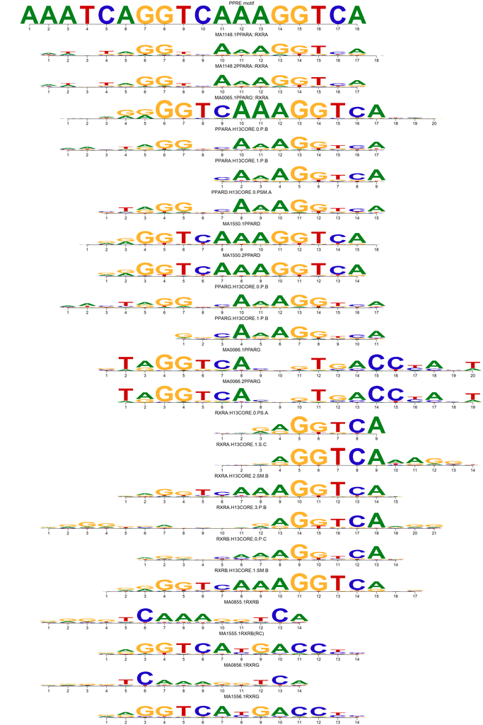

```r
plotMotifLogoStack(aligned_motifs_order, fontsize = 4, yaxis = FALSE, ylab = "", font = 'Arial')
```

# 3 PPRE Architecture Validation Figure

This figure checks whether the individual PPAR and RXR half-site motifs, plus the three full PPAR::RXR heterodimer motifs, recover the expected PPRE (DR1) architecture: a `AGGTCA`-like PPAR half-site, a 1 bp spacer, and a second `AGGTCA`-like RXR half-site. The synthetic `PPRE motif` reference itself is kept separate as the template.

Two consensus logos are built from the same 22 motifs and compared:

- **Manual alignment** — each motif is placed on a shared canvas at a hand-curated start column (with reverse-complementing where needed), based on where its `AGGTCA`-like core is known to sit.
- **Unsupervised alignment** — the same 22 motifs, but taken from the existing algorithmic `DNAmotifAlignment()` result (`aligned_motifs`) computed above, with no manual placement.

```r
# Hand-curated start column (on a shared canvas) and orientation for every
# individual motif, based on where its own AGGTCA-like core is known to sit.
# MA1555.1's source file already stores it reverse-complemented relative to
# the other RXR motifs, so it is flipped back here to align consistently.
manual_alignment <- data.frame(
  Motif_name = c(
    "MA1148.1\tPPARA::RXRA", "MA1148.2\tPPARA::RXRA", "MA0065.1\tPPARG::RXRA",

    "PPARA.H13CORE.0.P.B", "PPARA.H13CORE.1.P.B", "PPARD.H13CORE.0.PSM.A",
    "MA1550.1\tPPARD", "MA1550.2\tPPARD", "PPARG.H13CORE.0.P.B", "PPARG.H13CORE.1.P.B",
    "MA0066.1\tPPARG", "MA0066.2\tPPARG",

    "RXRA.H13CORE.0.PS.A", "RXRA.H13CORE.1.S.C", "RXRA.H13CORE.2.SM.B", "RXRA.H13CORE.3.P.B",
    "RXRB.H13CORE.0.P.C", "RXRB.H13CORE.1.SM.B",
    "MA0855.1\tRXRB", "MA1555.1\tRXRB", "MA0856.1\tRXRG", "MA1556.1\tRXRG"
  ),
  Start = c(
    2, 2, 2,
    2, 3, 4, 4, 5, 2, 1, 4, 5,
    10, 10, 5, 1, 6, 4, 5, 12, 5, 12
  ),
  Reverse_complement = c(
    FALSE, FALSE, FALSE,
    FALSE, FALSE, FALSE, FALSE, FALSE, FALSE, FALSE, FALSE, FALSE,
    FALSE, FALSE, FALSE, FALSE, FALSE, FALSE, FALSE, TRUE, FALSE, FALSE
  ),
  # Which guide box(es) this motif's core should land under: the three full
  # heterodimers span both half-sites, everything else spans just one
  Family = c(
    "BOTH", "BOTH", "BOTH",
    "PPAR", "PPAR", "PPAR", "PPAR", "PPAR", "PPAR", "PPAR", "PPAR", "PPAR",
    "RXR", "RXR", "RXR", "RXR", "RXR", "RXR", "RXR", "RXR", "RXR", "RXR"
  ),
  stringsAsFactors = FALSE
)

normalize_matrix <- function(mat) {
  mat <- mat[c("A", "C", "G", "T"), , drop = FALSE]
  mat[is.na(mat)] <- 0
  totals <- colSums(mat)
  informative <- totals > 0
  if (any(informative)) {
    mat[, informative] <- sweep(mat[, informative, drop = FALSE], MARGIN = 2, STATS = totals[informative], FUN = "/")
  }
  mat
}

# Reverse-complement a PFM: reverse column order and swap A<->T, C<->G rows
reverse_complement_matrix <- function(mat) {
  mat <- mat[c("T", "G", "C", "A"), ncol(mat):1, drop = FALSE]
  rownames(mat) <- c("A", "C", "G", "T")
  mat
}

place_on_canvas <- function(mat, start, canvas_width) {
  end <- start + ncol(mat) - 1
  if (start < 1 || end > canvas_width) {
    stop("Motif does not fit on canvas. Start = ", start, ", end = ", end, ", canvas width = ", canvas_width)
  }
  canvas <- matrix(0, nrow = 4, ncol = canvas_width, dimnames = list(c("A", "C", "G", "T"), seq_len(canvas_width)))
  canvas[, start:end] <- mat
  canvas
}

motifs_by_name <- setNames(pfm_list, vapply(pfm_list, function(motif) motif@name, character(1)))
motifs_by_name <- motifs_by_name[names(motifs_by_name) != "PPRE motif"]

missing_names <- setdiff(manual_alignment$Motif_name, names(motifs_by_name))
if (length(missing_names) > 0) {
  stop("These motifs were not found in pfm_list: ", paste(missing_names, collapse = ", "))
}

canvas_width <- max(vapply(seq_len(nrow(manual_alignment)), function(i) {
  manual_alignment$Start[i] + ncol(motifs_by_name[[manual_alignment$Motif_name[i]]]@mat) - 1
}, numeric(1)))

manual_aligned_matrices <- lapply(seq_len(nrow(manual_alignment)), function(i) {
  motif_name <- manual_alignment$Motif_name[i]
  mat <- normalize_matrix(motifs_by_name[[motif_name]]@mat)
  if (manual_alignment$Reverse_complement[i]) mat <- reverse_complement_matrix(mat)
  place_on_canvas(mat = mat, start = manual_alignment$Start[i], canvas_width = canvas_width)
})
names(manual_aligned_matrices) <- manual_alignment$Motif_name
```

```r
# Coverage-aware consensus: average only the motifs that actually cover each
# canvas position, then keep only positions covered by at least half of the
# 22 motifs. Without this trim, the few columns only 1-2 motifs happen to
# reach (the wide flanks of the longer heterodimer motifs) would dilute the
# consensus with near-background noise instead of being dropped.
n_motifs <- length(manual_aligned_matrices)
consensus_matrix <- matrix(0, nrow = 4, ncol = canvas_width, dimnames = list(c("A","C","G","T"), seq_len(canvas_width)))
position_coverage <- numeric(canvas_width)
for (position in seq_len(canvas_width)) {
  contributing <- vapply(manual_aligned_matrices, function(mat) sum(mat[, position]) > 0, logical(1))
  position_coverage[position] <- sum(contributing)
  if (any(contributing)) {
    position_values <- vapply(manual_aligned_matrices[contributing], function(mat) mat[, position], numeric(4))
    consensus_matrix[, position] <- rowMeans(position_values)
  }
}

minimum_coverage <- ceiling(n_motifs / 2)
positions_to_keep <- position_coverage >= minimum_coverage

manual_consensus <- consensus_matrix[, positions_to_keep, drop = FALSE]
manual_consensus <- sweep(manual_consensus, 2, colSums(manual_consensus), "/")
colnames(manual_consensus) <- seq_len(ncol(manual_consensus))

manual_pfm <- new("pfm", mat = manual_consensus, name = "Consensus from manual alignment")
```

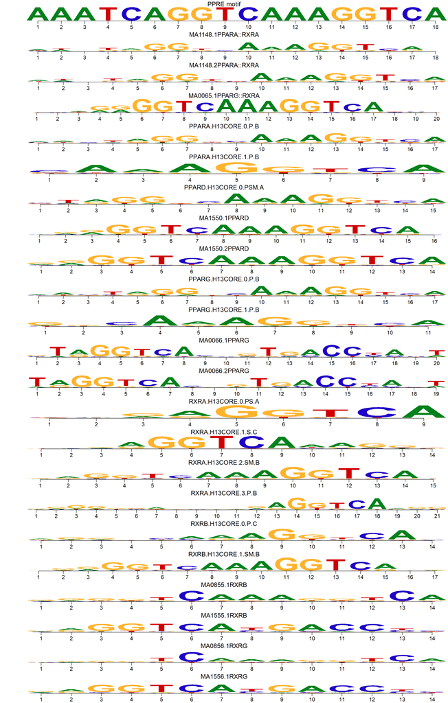

```r
# Every individually-placed motif plotted on its own, with the PPRE template
# on top for reference
stack_pfms <- c(
  list(`PPRE motif` = new("pfm", mat = normalize_matrix(PPRE_mat), name = "PPRE motif")),
  lapply(seq_len(nrow(manual_alignment)), function(i) {
    motif_name <- manual_alignment$Motif_name[i]
    mat <- normalize_matrix(motifs_by_name[[motif_name]]@mat)
    if (manual_alignment$Reverse_complement[i]) mat <- reverse_complement_matrix(mat)
    new("pfm", mat = mat, name = motif_name)
  })
)
plotMotifLogoStack(rev(stack_pfms), fontsize = 3, yaxis = FALSE, ylab = "", font = "Arial")
```

```r
# Same 22 motifs, but pulled from the existing DNAmotifAlignment() result
# instead of being manually placed. DNAmotifAlignment() appends "(RC)" to the
# @name of motifs it decides to flip during alignment, so match on the name
# with any "(RC)" suffix stripped.
strip_rc <- function(x) sub("\\(RC\\)$", "", x)
aligned_names <- sapply(aligned_motifs, function(m) m@name)
unsupervised_idx <- match(strip_rc(manual_alignment$Motif_name), strip_rc(aligned_names))
stopifnot(!any(is.na(unsupervised_idx)))

unsupervised_mats <- lapply(aligned_motifs[unsupervised_idx], function(m) m@mat)
common_width <- unique(vapply(unsupervised_mats, ncol, integer(1)))
stopifnot(length(common_width) == 1)  # DNAmotifAlignment() pads all motifs to equal width

unsupervised_stack <- array(NA_real_, dim = c(4, common_width, length(unsupervised_mats)))
for (i in seq_along(unsupervised_mats)) unsupervised_stack[,,i] <- unsupervised_mats[[i]]

unsupervised_consensus <- apply(unsupervised_stack, c(1,2), mean, na.rm = TRUE)
unsupervised_consensus[is.nan(unsupervised_consensus)] <- 0.25
unsupervised_consensus <- sweep(unsupervised_consensus, 2, colSums(unsupervised_consensus), "/")
rownames(unsupervised_consensus) <- c("A","C","G","T")

unsupervised_pfm <- new("pfm", mat = unsupervised_consensus, name = "Consensus from unsupervised alignment")
```

```r
# Rendered with motifStack's own plotMotifLogo (same Cairo engine, same
# "Information content" y-axis as panels 2/3 below), not a hand-drawn
# reconstruction. PPRE_mat is deterministic (one base per column at
# probability 1), so every position reaches the maximum 2 bits and the
# letters fill the full plot height.
ppre_pfm <- new("pfm", mat = normalize_matrix(PPRE_mat), name = "PPRE motif")

# margins match panels 2/3's y-axis gutter (left = 4.1 lines); extra top
# margin leaves room for the "PPAR motif" / "RXR motif" labels above the
# boxes, below the "PPRE motif" title
ppre_reference_grob <- grid::grid.grabExpr({
  plotMotifLogo(pfm = ppre_pfm, motifName = "PPRE motif", p = ppre_pfm@background,
                colset = ppre_pfm@color, yaxis = TRUE, ylab = "Information content", xlab = NA,
                margins = c(1.5, 4.1, 6.5, 1.0), newpage = FALSE)

  # data region occupies roughly npc [0.10, 0.98] once the y-axis gutter is
  # accounted for; calibrated against the rendered axis tick positions
  left_frac <- 0.10
  right_frac <- 0.98
  col_width <- (right_frac - left_frac) / 18
  ppar_box <- left_frac + c(5, 11) * col_width
  rxr_box  <- left_frac + c(12, 18) * col_width

  box_bottom <- 0
  box_top <- 0.88
  for (box in list(ppar_box, rxr_box)) {
    grid.rect(x = unit(mean(box), "npc"), y = unit((box_bottom + box_top) / 2, "npc"),
              width = unit(diff(box), "npc"), height = unit(box_top - box_bottom, "npc"),
              gp = gpar(col = "red", fill = NA, lwd = 2.5))
  }
  grid.text("PPAR motif", x = unit(mean(ppar_box), "npc"), y = unit(box_top + 0.03, "npc"),
            just = c("center", "bottom"), gp = gpar(fontface = "bold", fontsize = 13))
  grid.text("RXR motif", x = unit(mean(rxr_box), "npc"), y = unit(box_top + 0.03, "npc"),
            just = c("center", "bottom"), gp = gpar(fontface = "bold", fontsize = 13))
})
grid.newpage()
grid.draw(ppre_reference_grob)
```

```r
panel2_grob <- grid::grid.grabExpr(
  plotMotifLogo(manual_pfm, motifName = "Consensus from manual alignment", ylab = "Information content", margins = c(4.1, 4.1, 2.1, 0.1))
)
panel3_grob <- grid::grid.grabExpr(
  plotMotifLogo(unsupervised_pfm, motifName = "Consensus from unsupervised alignment", ylab = "Information content", margins = c(4.1, 4.1, 2.1, 0.1))
)

pdf("data/PPAR_RXR_motifs_Hocomoco_Jaspar/Objective1_results/PPRE_architecture_validation.pdf", width = 10, height = 12)
grid.arrange(ppre_reference_grob, panel2_grob, panel3_grob, ncol = 1, heights = c(1.3, 1, 1))
dev.off()
```

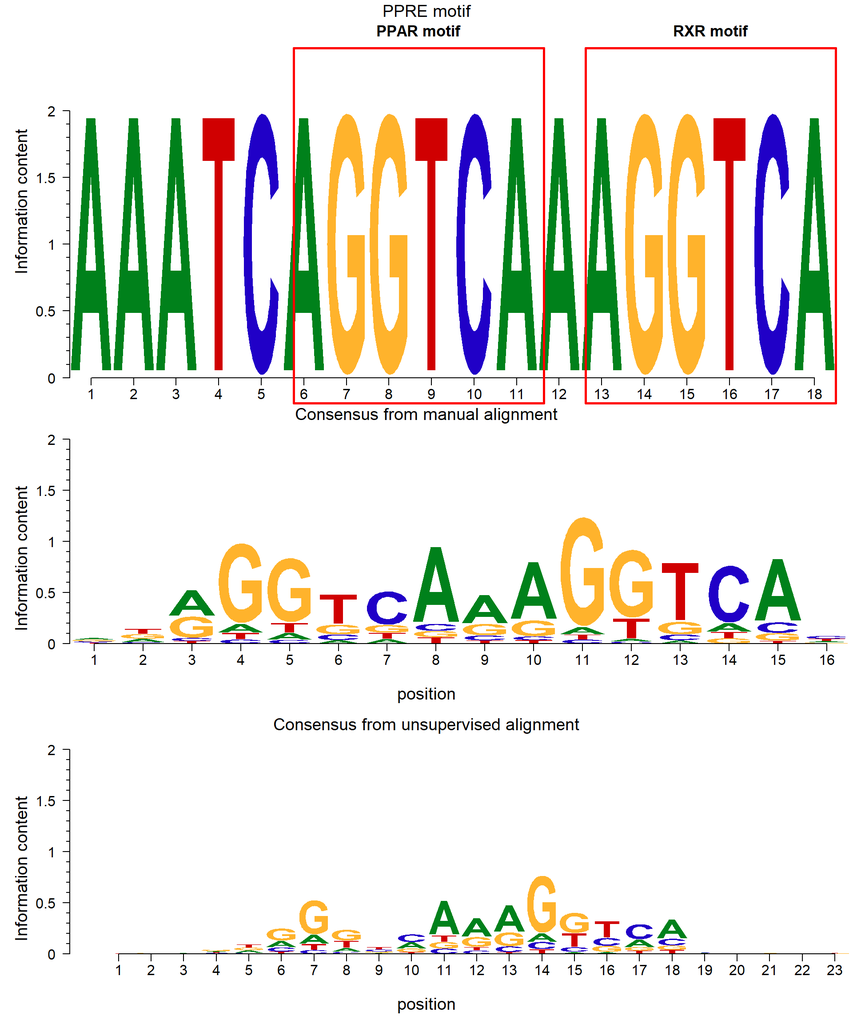

```r
grid.arrange(ppre_reference_grob, panel2_grob, panel3_grob, ncol = 1, heights = c(1.3, 1, 1))
```

# 4 Convert to MEME Format for FIMO Input

```r
# Motif order going into the MEME export, for reference against the batch files below
motif_names
```

```
##                  length
##   "PPARA.H13CORE.0.P.B"   "PPARA.H13CORE.1.P.B" "PPARD.H13CORE.0.PSM.A"
##
##   "PPARG.H13CORE.0.P.B"   "PPARG.H13CORE.1.P.B"   "RXRA.H13CORE.0.PS.A"
##
##    "RXRA.H13CORE.1.S.C"   "RXRA.H13CORE.2.SM.B"    "RXRA.H13CORE.3.P.B"
##
##    "RXRB.H13CORE.0.P.C"   "RXRB.H13CORE.1.SM.B" "MA0065.1\tPPARG::RXRA"
##
##       "MA0066.1\tPPARG"       "MA0066.2\tPPARG"        "MA0855.1\tRXRB"
##
##        "MA0856.1\tRXRG" "MA1148.1\tPPARA::RXRA" "MA1148.2\tPPARA::RXRA"
##
##       "MA1550.1\tPPARD"       "MA1550.2\tPPARD"    "MA1555.1\tRXRB(RC)"
##
##        "MA1556.1\tRXRG"            "PPRE motif"
```

```r
write_meme(meme_list[1:4], "data/PPAR_RXR_motifs_Hocomoco_Jaspar/RXR_PPAR_combined_files_1_4.meme" ,overwrite = TRUE)
write_meme(meme_list[5:8], "data/PPAR_RXR_motifs_Hocomoco_Jaspar/RXR_PPAR_combined_files_5_8.meme" ,overwrite = TRUE)
write_meme(meme_list[9:12], "data/PPAR_RXR_motifs_Hocomoco_Jaspar/RXR_PPAR_combined_files_9_12.meme" ,overwrite = TRUE)
write_meme(meme_list[13:16], "data/PPAR_RXR_motifs_Hocomoco_Jaspar/RXR_PPAR_combined_files_13_16.meme" ,overwrite = TRUE )
write_meme(meme_list[17:20], "data/PPAR_RXR_motifs_Hocomoco_Jaspar/RXR_PPAR_combined_files_17_20.meme" , overwrite = TRUE)
write_meme(meme_list[21:22], "data/PPAR_RXR_motifs_Hocomoco_Jaspar/RXR_PPAR_combined_files_21_22.meme" , overwrite = TRUE)
```